# Categorical class 2

# Packages

```r
library(Stat2Data)
library(ggplot2)
library(dplyr)
```

- Sometimes you get messages that a package has a function with the same name as a function in another package
  - This is saying that since you loaded **dplyr**, if it sees these functions that are listed, it will use the **dplyr** version of them instead of the other version

# Data

- **Stat2Data** package: [info here](https://cran.r-project.org/web/packages/Stat2Data/index.html)
  - `MedGPA` dataset ($n$ = 55)
    - `Acceptance`: accepted in medical school (0 = no, 1 = yes)
    - `Sex`: F=female or M=male
    - `BCPM`: Bio/Chem/Physics/Math grade point average
    - `GPA`: College grade point average
    - `VR`: Verbal reasoning (subscore)
    - `PS`: Physical sciences (subscore)
    - `WS`: Writing sample (subcore)
    - `BS`: Biological sciences (subscore)
    - `MCAT`: Score on the MCAT exam (sum of VR+PS+WS+BS)
    - `Apps`: Number of medical schools applied to
- When you use a dataset that’s in a package, you don’t read it in the same way
  - Load the package: `library(Stat2Data)`
  - Load the dataset: `data(MedGPA)`
  - The data is in a dataframe with the same name: `MedGPA`

```r
library(Stat2Data)
data(MedGPA)
head(MedGPA)
```

```
  Accept Acceptance Sex BCPM  GPA VR PS WS BS MCAT Apps
1      D          0   F 3.59 3.62 11  9  9  9   38    5
2      A          1   M 3.75 3.84 12 13  8 12   45    3
3      A          1   F 3.24 3.23  9 10  5  9   33   19
4      A          1   F 3.74 3.69 12 11  7 10   40    5
5      A          1   F 3.53 3.38  9 11  4 11   35   11
6      A          1   M 3.59 3.72 10  9  7 10   36    5
```

# Models

## `GPA` predicts `Acceptance`

### Scatterplot of `Acceptance` (Y) vs `GPA` (X)

- The options in `geom_smooth()` tell it to fit a logistic regression curve
  - `method = "glm"` : use a generalized linear model
  - `method.args = list(family = "binomial")` : specifically, use a logistic regression (i.e., binomial outcome)

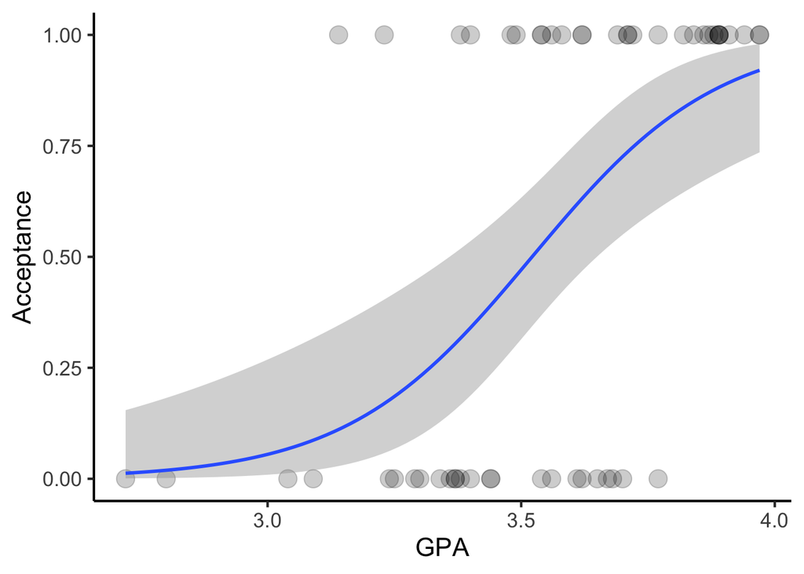

```r
ggplot(data = MedGPA, aes(x = GPA, y = Acceptance)) +
    geom_point(alpha = 0.2, size = 5) +
    geom_smooth(method = "glm",
                method.args = list(family = "binomial"),
                se = TRUE)
```

### Logistic regression model

- `GPA` is centered at its mean (3.553)
- `glm()` works very much like `lm()`
  - Additional options specify the type of GLiM
    - Here, logistic regression (with **binomial outcome distribution** and **logit link function**) is specified by `family = binomial(link = "logit")`

```r
MedGPA <- MedGPA %>% mutate(GPAc = GPA - mean(GPA))
Acc_GPA <- glm(Acceptance ~ GPAc, MedGPA, family = binomial(link = "logit"))
```

#### `summary()` of the model

```r
summary(Acc_GPA)
```

```
Call:
glm(formula = Acceptance ~ GPAc, family = binomial(link = "logit"),
    data = MedGPA)

Deviance Residuals:
    Min       1Q   Median       3Q      Max
-1.7805  -0.8522   0.4407   0.7819   2.0967

Coefficients:
            Estimate Std. Error z value Pr(>|z|)
(Intercept)   0.1736     0.3253   0.534 0.593488
GPAc          5.4542     1.5792   3.454 0.000553 ***
---
Signif. codes:  0 '***' 0.001 '**' 0.01 '*' 0.05 '.' 0.1 ' ' 1

(Dispersion parameter for binomial family taken to be 1)

    Null deviance: 75.791  on 54  degrees of freedom
Residual deviance: 56.839  on 53  degrees of freedom
AIC: 60.839

Number of Fisher Scoring iterations: 4
```

- We can look at just the coefficients using the `coefficients()` function

```r
coefficients(Acc_GPA)
```

```
(Intercept)        GPAc
  0.1736361   5.4541659
```

- And we can select individual coefficients using `[]` for the element
  - Intercept is `[1]`
  - First predictor is `[2]`
  - Second predictor (if it exists) is `[3]`
- I’m going to save these as variables so we can call them later

```r
GPA_b0 <- coefficients(Acc_GPA)[1]
names(GPA_b0) <- NULL
GPA_b1 <- coefficients(Acc_GPA)[2]
names(GPA_b1) <- NULL
```

- The statements involving `NULL` are just dropping the column labels from those variables
  - Otherwise the labels will follow them around whenever we use the variables

### Interpretation

#### Intercept

- Probability of acceptance when `GPAc` = 0
  - $P(success|X = 0) = \frac{e^{b_0}}{1 + e^{b_0}}$ =

```r
prob_X0 <- exp(GPA_b0) / (1 + exp(GPA_b0))
prob_X0
```

```
[1] 0.5433003
```

- A person with `GPAc` = 0 (mean `GPA`) has 0.54 probability of being accepted to med school
  - Greater than 0.5, so more likely to be accepted than not
- You can also convert this to odds:

```r
odds_X0 <- prob_X0 / (1 - prob_X0)
odds_X0
```

```
[1] 1.189623
```

- A person with `GPAc` = 0 (mean `GPA`) has 1.19 odds of being accepted to med school
  - Greater than 1, so more likely to be accepted than not
- And let’s go wild and convert it to logit too:

```r
logit_X0 <- log(odds_X0)
logit_X0
```

```
[1] 0.1736361
```

- A person with `GPAc` = 0 (mean `GPA`) has 0.174 logit of being accepted to med school
  - Positive, so more likely to be accepted than not

#### Slope

- From the slope, you can calculate the **odds ratio**

```r
odds_ratio <- exp(GPA_b1)
odds_ratio
```

```
[1] 233.7298
```

- The odds ratio is the multiplicative change in the *odds* for a 1 unit change in the predictor
  - **Constant** multiplicative change
  - For every 1 unit increase in `GPAc`, we expect the predicted odds to get **multiplied** by 233.73
- For probability metric, use the predicted values instead (below)
- For logit metric, it’s just a linear effect

#### Predicted values

- This is just one way to do this that I find the easiest
  - Grab the $b_0$ and $b_1$ values from the output
    - We already saved these above as variables: `GPA_b0` and `GPA_b1`
  - Create some X values that correspond to the predictor
    - Centered `GPA` ranges from about $-1$ to about $+0.5$
    - Don’t include too many values or the table will get too large
  - Calculate the predicted probability using the equations from lecture
    - Calculate the slope for the probability line using that
  - Use that to calculate predicted odds and predicted logit
  - Combine all the variables into a data frame

```r
x <- c(-1, -0.75, -0.5, -0.25, 0, 0.25, 0.5)
pred_prob <- exp(GPA_b0 + GPA_b1 * x) / (1 + exp(GPA_b0 + GPA_b1 * x))
pred_prob_slope <- pred_prob*(1 - pred_prob)*GPA_b1
pred_odds <- pred_prob / (1 - pred_prob)
pred_logit <- log(pred_odds)
predicted <- data.frame(x, pred_prob, pred_prob_slope, pred_odds, pred_logit)
predicted
```

```
      x   pred_prob pred_prob_slope    pred_odds pred_logit
1 -1.00 0.005063959      0.02747981  0.005089734 -5.2805298
2 -0.75 0.019512621      0.10434844  0.019900940 -3.9169883
3 -0.50 0.072195265      0.36533699  0.077812995 -2.5534468
4 -0.25 0.233275865      0.97552249  0.304250061 -1.1899053
5  0.00 0.543300297      1.35331538  1.189622620  0.1736361
6  0.25 0.823054058      0.79432332  4.651443540  1.5371776
7  0.50 0.947881973      0.26944528 18.187218896  2.9007191
```

- If you’re using markdown or Quarto with R, you can print the table in HTML with formatting to look nicer and be a bit easier to read

```r
knitr::kable(predicted, digits = 2, row.names = F)
```

| x | pred_prob | pred_prob_slope | pred_odds | pred_logit |
| --- | --- | --- | --- | --- |
| -1.00 | 0.01 | 0.03 | 0.01 | -5.28 |
| -0.75 | 0.02 | 0.10 | 0.02 | -3.92 |
| -0.50 | 0.07 | 0.37 | 0.08 | -2.55 |
| -0.25 | 0.23 | 0.98 | 0.30 | -1.19 |
| 0.00 | 0.54 | 1.35 | 1.19 | 0.17 |
| 0.25 | 0.82 | 0.79 | 4.65 | 1.54 |
| 0.50 | 0.95 | 0.27 | 18.19 | 2.90 |

## `Apps` predicts `Acceptance`

### Scatterplot of `Acceptance` (Y) vs `Apps` (X)

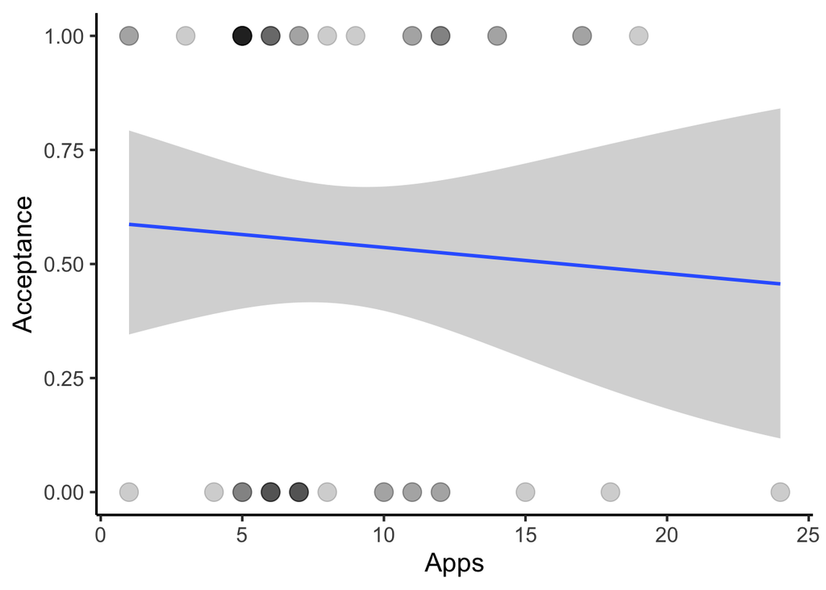

```r
ggplot(data = MedGPA, aes(x = Apps, y = Acceptance)) +
    geom_point(alpha = 0.2, size = 5) +
    geom_smooth(method = "glm",
                method.args = list(family = "binomial"),
                se = TRUE)
```

- This doesn’t look much like the S-shaped curve we saw before, does it?
  - That’s because it’s a **very flat curve** and we only see a tiny part of it
  - Let’s zoom out using
    - `xlim(-100, 100)` in `ggplot()` to expand the X axis from -100 to 100
    - `fullrange = TRUE` option in the `geom_smooth()` to extend the line

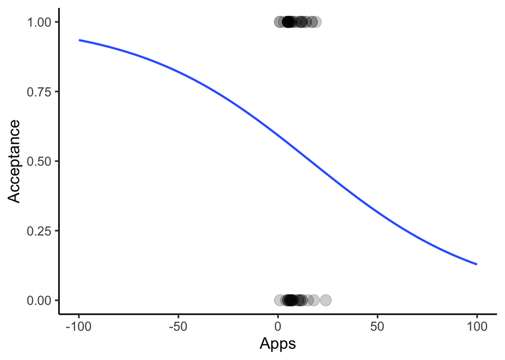

```r
ggplot(data = MedGPA, aes(x = Apps, y = Acceptance)) +
    geom_point(alpha = 0.2, size = 5) +
    geom_smooth(method = "glm",
                method.args = list(family = "binomial"),
                se = FALSE,
                fullrange = TRUE) +
    xlim(-100, 100)
```

- Two things:
  - See? It really is an S-shaped curve, it’s just backward
  - This backwards S corresponds to a **negative** slope
  - So let’s look at the model

### Logistic regression model

```r
Acc_Apps <- glm(Acceptance ~ Apps, MedGPA, family = binomial(link = "logit"))
summary(Acc_Apps)
```

```
Call:
glm(formula = Acceptance ~ Apps, family = binomial(link = "logit"),
    data = MedGPA)

Deviance Residuals:
   Min      1Q  Median      3Q     Max
-1.330  -1.270   1.051   1.083   1.203

Coefficients:
            Estimate Std. Error z value Pr(>|z|)
(Intercept)  0.37403    0.55447   0.675    0.500
Apps        -0.02287    0.05761  -0.397    0.691

(Dispersion parameter for binomial family taken to be 1)

    Null deviance: 75.791  on 54  degrees of freedom
Residual deviance: 75.633  on 53  degrees of freedom
AIC: 79.633

Number of Fisher Scoring iterations: 3
```

- The slope (`Apps` effect) is negative, but not significant

# Class task

1. Create a scatterplot of `Acceptance` vs `MCAT`
2. Run a logistic regression model with `MCAT` predicting `Acceptance`
   - Center `MCAT` at its mean
3. Interpret the coefficients from the model
   - Use the predicted values (probability, odds, logit) to help you

# Questions for next time

- `MCAT` and `GPA` are prety highly correlated: $r = 0.54$
  - Should we include them in the same model?
  - How do we talk about that?
- How much variance in `Acceptance` is explained by these predictors?
  - Individually or in a model with multiple predictors
  - Some measure like $R^2$